# MetaAnalysis Assignment

Renée Claes and Maxime Keutgen

2021-04-11

## Introduction

In this notebook, we try to reproduce some of the results of the Meta-Analysis of Hornsey & al 2016. We start by loading libraries and datasets.

```r
library(haven)
library(metafor)
library(tidyverse)
library(meta)
NEP <- read_sav("NEP.sav")
ObjKnow      <- read_sav("Objective Knowledge.sav")
SubjKnow <- read_sav("Subjective Knowledge.sav")
FreeMark <- read_sav("Support for Free-market Ideology.sav")
TrustScientist <- read_sav("Trust in Scientists.sav")
```

## Objective knowledge

First, we will start with one dataset, objective knowledge. A bit of data cleaning is required (shortening name of one study).

```r
ObjKnow[15,1] <- "Hine, D. W., Reser et al (2013)"
```

Also, we need an estimate of the variance of the effect size. Since these are correctional studies, the correlations coefficients have been transformed to Fisher Z scores$^1$ for inferential purposes. The correctional coefficient is given by :
$$r = \frac{cov(X,Y)}{\sigma_X\sigma_Y}$$
Fisher transformation is given by :
$$z = \frac{1}{2} ln \bigg(\frac{1+r}{1-r} \bigg)$$
If $X_1..X_n$ and $Y_1,..,Y_n$ are i.i.d paired data, then $z$ is asymptotically normally distributed$^2$ :
$$z \sim \mathcal{N} \Bigg(\frac{1}{2}ln\bigg(\frac{1+r}{1-r}\bigg),\frac{1}{N-3} \Bigg)$$
We can then compute the variance of the Fisher Z-scores and the variance .

```r
ObjKnow <- ObjKnow %>% mutate(Var=1/(Sample_size-3),Cor=tanh(FishersZ) )
```

We now have at our disposal point estimate of the effect size (Z scores) and of the variance of this effect size. We start by fitting a Random Effect model.

```r
REM.metafor <- rma(vi = ObjKnow$var,method = "REML",ri = ObjKnow$Cor,measure="COR",ni=ObjKnow$Sample_size)
```

Random effect models with RMA function has an estimate of 0.2302, ci 0.11-0.34

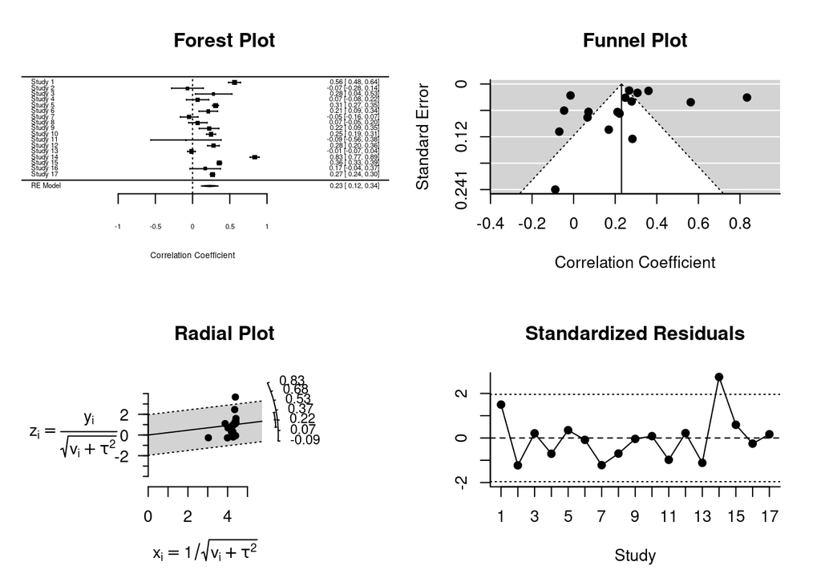

```r
plot.rma.uni(REM.metafor)
```

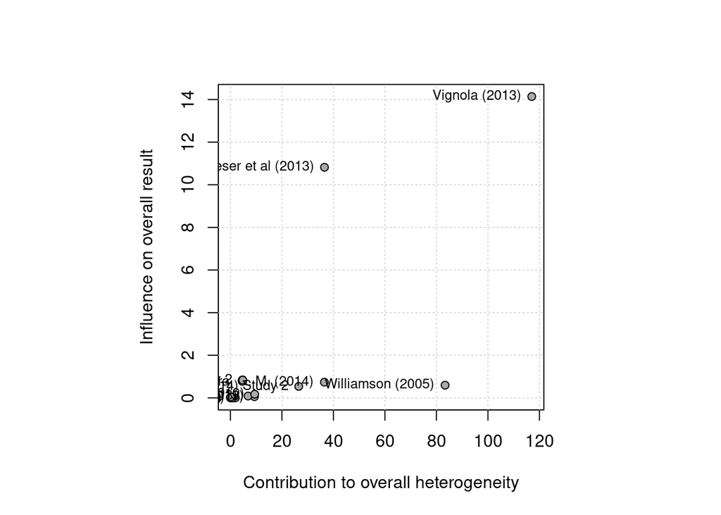

```r
REM.meta <- metacor(cor = Cor,n=Sample_size,studlab = Study_name,comb.random = T,data = ObjKnow,method.tau = "REML")

baujat.meta(REM.meta)
```

```r
REM.meta <- metacor(cor = Cor,n=Sample_size,studlab = Study_name,comb.random = T,data = ObjKnow,method.tau = "REML")
```

Estimate : 0.2464, 95% CI :[0.1097; 0.3740]. Estimator of tau^2 is REML. Should we use different estimators ? The results agreed with article figure 2 from article. Test for heterogeneity is significant. Tau is an estimate of between study variance, I^2 heterogeneity.

We can now also do funnel plots and forestplots. Should be nice to do them in ggplot.

```r
t <- tibble(ObjKnow$Study_name,tanh(REM.meta$lower),tanh(REM.meta$upper),
            REM.meta$cor,floor(ObjKnow$Sample_size))
names(t) <- c("name","lower","upper","estimate","sample.size")
t <- t %>% add_row(name="A. Overall association",lower=REM.meta$lower.random,upper=REM.meta$upper.random,
                   estimate=REM.meta$TE.random,sample.size=floor(sum(ObjKnow$Sample_size)))
t %>% filter(name=="Williamson (2005)")
```

```
## # A tibble: 1 x 5
##   name              lower upper estimate sample.size
##   <chr>             <dbl> <dbl>    <dbl>       <dbl>
## 1 Williamson (2005) 0.762 0.885    0.834          99
```

```r
t$type <- ifelse(t$name=="A. Overall association","Combined","Not combined")
```

Forest plot

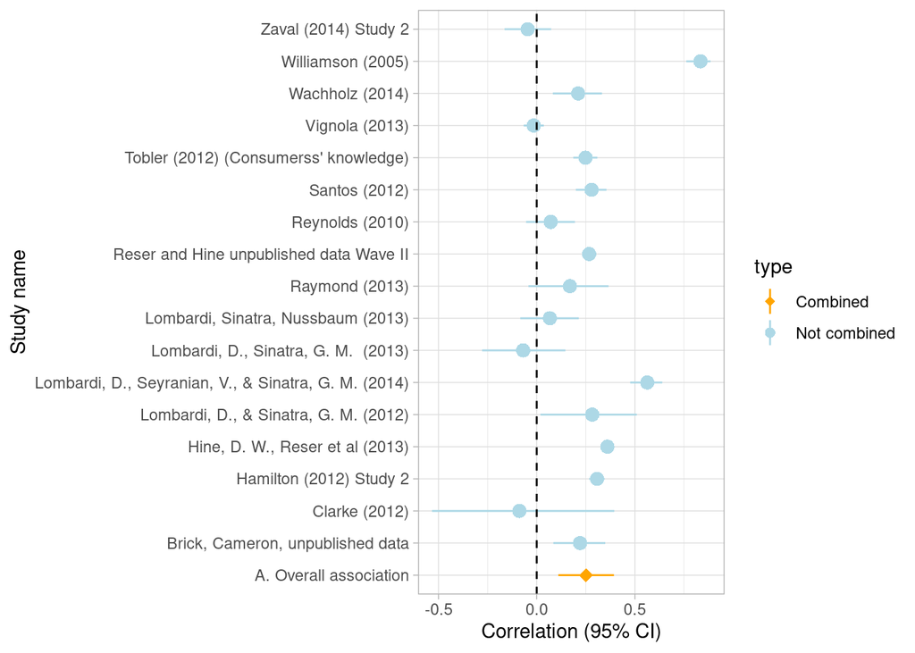

```r
fp <- ggplot(data=t, aes(x=name, y=estimate, ymin=lower, ymax=upper,shape=type)) +
        geom_pointrange(aes(color=type),fatten = 6) +
        geom_hline(yintercept=0, lty=2) +  # add a dotted line at x=1 after flip
        coord_flip() +  # flip coordinates (puts labels on y axis)
        xlab("Study name") + ylab("Correlation (95% CI)") +
        scale_shape_manual(values=c(18,16)) + scale_color_manual(values = c("orange","lightblue"))+theme_light()
print(fp)
```

What about Funnel Plot ?

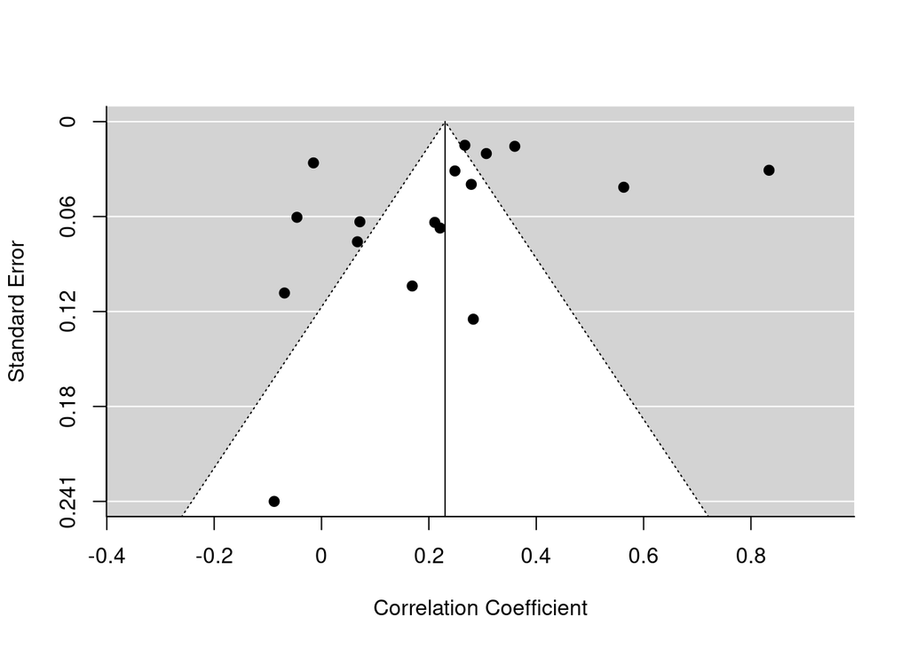

```r
funnel(REM.metafor)
```

Commentary of the funnel plot : There seems to be considerable publication bias. In particular, the study of Williamson, with a reported correlation of 0.8 looks astonishing. One should investigate further.

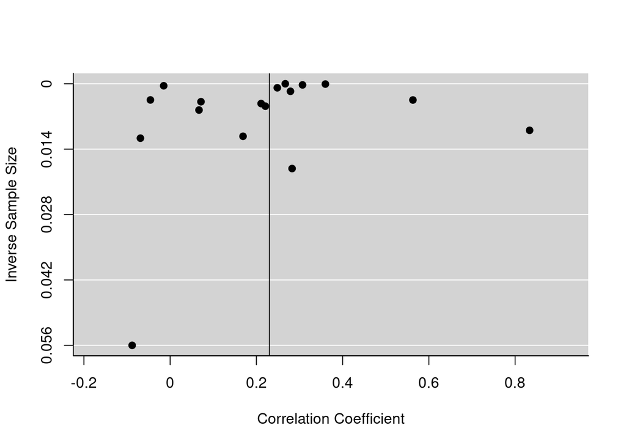

```r
funnel(REM.metafor,yaxis="ninv")
```

How sensible is the meta-analysis to study 14 ? Let’s construct a hypothesis test. We know that the Fisher transform of correlations coefficients is normally distributed. We also know that the sum of normally distributed random variables is also normally distributed. We can thus construct a z-statistic :
$$z = \frac{arctanh(r_1') - arctanh(r_2')}{S} \sim N(0,1)$$

With S a pooled estimate of the two estimates of variances of the Fisher transform of the regression estimates :
$$S = \sqrt{S_{r_1'}^2 + S^2_{r_2'}}$$

```r
set.seed(1)
random.sel <- sample(17,16)
with.study14 <- ObjKnow[random.sel,]
rma.study14 <- metacor(cor = Cor,n=Sample_size,studlab = Study_name,comb.random = T,data = with.study14)
wo.study14 <- ObjKnow[-14,]
rma.wo.study14 <- metacor(cor = Cor,n=Sample_size,studlab = Study_name,comb.random = T,data = wo.study14)
```

In this section, we try to replicate the use of moderators.

```r
REM.group.country <- metacor(cor = Cor,n=Sample_size,studlab = Study_name,comb.random = T,data = ObjKnow,byvar = ObjKnow$Country,comb.fixed = F)
summary(REM.group.country)
```

```
## Number of studies combined: k = 17
##
##                         COR           95%-CI    z  p-value
## Random effects model 0.2485 [0.1641; 0.3293] 5.64 < 0.0001
##
## Quantifying heterogeneity:
##  tau^2 = 0.0285 [0.0241; 0.1409]; tau = 0.1688 [0.1553; 0.3753]
##  I^2 = 95.2% [93.6%; 96.4%]; H = 4.57 [3.95; 5.30]
##
## Test of heterogeneity:
##       Q d.f.  p-value
##  334.59   16 < 0.0001
##
## Results for subgroups (random effects model):
##                          k     COR            95%-CI  tau^2    tau     Q   I^2
## Country = USA            9  0.1912 [ 0.0563; 0.3192] 0.0381 0.1952 94.40 91.5%
## Country = Switzerland    1  0.2485 [ 0.1863; 0.3088]     --     --  0.00    --
## Country = South Africa   2  0.1834 [-0.1397; 0.4712] 0.0360 0.1898  2.05 51.3%
## Country = Costa Rica     1 -0.0150 [-0.0662; 0.0363]     --     --  0.00    --
## Country = Canda          1  0.8337 [ 0.7616; 0.8854]     --     --  0.00    --
## Country = Australia      3  0.2947 [ 0.2062; 0.3784] 0.0051 0.0714 20.14 90.1%
##
## Test for subgroup differences (random effects model):
##                       Q d.f.  p-value
## Between groups   165.59    5 < 0.0001
##
## Details on meta-analytical method:
## - Inverse variance method
## - DerSimonian-Laird estimator for tau^2
## - Jackson method for confidence interval of tau^2 and tau
## - Fisher's z transformation of correlations
```

## References

[1] Fisher, R. A. (1915). “Frequency distribution of the values of the correlation coefficient in samples of an indefinitely large population”. Biometrika. 10 (4): 507–521. doi:10.2307/2331838. hdl:2440/15166. JSTOR 2331838

[2] Fisher, R. A. (1921). “On the ‘probable error’ of a coefficient of correlation deduced from a small sample” (PDF). Metron. 1: 3–32.

[3] Williamson, T., Parkins, J., & McFarlane, B. (2005). Perceptions of climate change risk to forest ecosystems and forest-based communities. The Forestry Chronicle, 81, 710-716